# Exploratory data analysis

Data visualization hw3

Ivan Prodaiko

```r
loadLibs <- function() {
  library(dplyr)
  library(tidyr)
  library(ggplot2)
  library(ggbeeswarm)
  library(ggridges)
  library(ggthemes)
  library(ggrepel)
  library(reshape2)
  library(purrr)
  library(Hmisc)
}
suppressMessages(loadLibs())

remove_outliers <- function(x, na.rm = TRUE, ...) {
  qnt <- quantile(x, probs=c(.05, .95), na.rm = na.rm, ...)
  H <- 1.5 * IQR(x, na.rm = na.rm)
  y <- x
  y[x < (qnt[1] - H)] <- NA
  y[x > (qnt[2] + H)] <- NA
  y
}
```

### Load dataset:

```r
df <- read.csv("./music.csv", header = T)
head(df)
```

|  | artist.hotttnesss | artist.id | artist.name | artist_mbtags | artist_mbtags_count | bars_confidence | bars_start | beats_confidence | beats_start | duration | end_of_fade_in | familiarity | key | key_confidence | latitude | location | longitude | loudness | mode | mode_confidence | release.id | release.name | similar | song.hotttnesss | song.id | start_of_fade_out | tatums_confidence | tatums_start | tempo | … |
| --- | --- | --- | --- | --- | --- | --- | --- | --- | --- | --- | --- | --- | --- | --- | --- | --- | --- | --- | --- | --- | --- | --- | --- | --- | --- | --- | --- | --- | --- | --- |
| 1 | 0.4019975 | ARD7TVE1187B99BFB1 | Casual |  | 0 | 0.643 | 0.58521 | 0.834 | 0.58521 | 218.9318 | 0.247 | 0.5817938 | 1 | 0.736 | 37.15736 | California - LA | -63.93336 | -11.197 | 0 | 0.636 | 300848 | Fear Itself | ARV4KO21187FB38008 | 0.6021200 | SOMZWCG12A8C13C480 | 218.932 | 0.779 | 0.28519 | 92.198 | … |
| 2 | 0.4174996 | ARMJAGH1187FB546F3 | The Box Tops | classic pop and rock | 1 | 0.007 | 0.71054 | 1.000 | 0.20627 | 148.0355 | 0.148 | 0.6306300 | 6 | 0.169 | 35.14968 | Memphis, TN | -90.04892 | -9.843 | 0 | 0.430 | 300822 | Dimensions | ARSZWK21187B9B26D7 | NA | SOCIWDW12A8C13D406 | 137.915 | 0.969 | 0.20627 | 121.274 | … |
| 3 | 0.3434284 | ARKRRTF1187B9984DA | Sonora Santanera |  | 0 | 0.980 | 0.73152 | 0.980 | 0.73152 | 177.4755 | 0.282 | 0.4873568 | 8 | 0.643 | 37.15736 | Not available | -63.93336 | -9.689 | 1 | 0.565 | 514953 | Las Numero 1 De La Sonora Santanera | ARFSJUG11C8A421AAD | NA | SOXVLOJ12AB0189215 | 172.304 | 0.482 | 0.42132 | 100.070 | … |
| 4 | 0.4542312 | AR7G5I41187FB4CE6C | Adam Ant | uk | 1 | 0.017 | 1.30621 | 0.809 | 0.81002 | 233.4036 | 0.000 | 0.6303823 | 0 | 0.751 | 37.15736 | London, England | -63.93336 | -9.013 | 1 | 0.749 | 287650 | Friend Or Foe | AR4R0741187FB39AF2 | NA | SONHOTT12A8C13493C | 217.124 | 0.601 | 0.56254 | 119.293 | … |
| 5 | 0.4017237 | ARXR32B1187FB57099 | Gob |  | 0 | 0.175 | 1.06368 | 0.883 | 0.13576 | 209.6061 | 0.066 | 0.6510457 | 2 | 0.092 | 37.15736 | Not available | -63.93336 | -4.501 | 1 | 0.371 | 611336 | Muertos Vivos | ARUA62A1187B99D9B0 | 0.6045007 | SOFSOCN12A8C143F5D | 198.699 | 1.000 | 0.13576 | 129.738 | … |
| 6 | 0.3854706 | ARKFYS91187B98E58F | Jeff And Sheri Easter |  | 0 | 0.121 | 1.17118 | 0.438 | 0.74856 | 267.7024 | 2.264 | 0.5352927 | 5 | 0.635 | 37.15736 | Not available | -63.93336 | -9.323 | 1 | 0.557 | 41838 | Ordinary Day | ARHNMEZ11F50C4706C | NA | SOYMRWW12A6D4FAB14 | 254.270 | 0.136 | 0.53929 | 147.782 | … |

### Lets first of all look the distributions of main features:

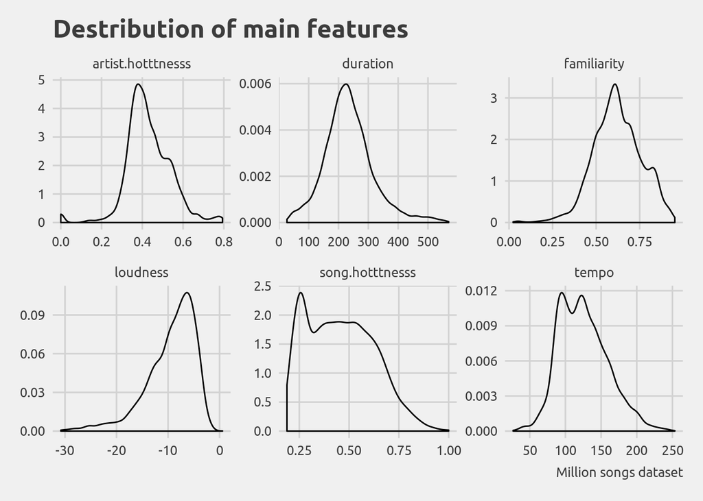

```r
mainfeatures <- df %>% select(c("artist.hotttnesss", "duration", "tempo", "song.hotttnesss", "loudness", "familiarity"))

as.data.frame(sapply(mainfeatures, remove_outliers)) %>%
  filter_at(vars(song.hotttnesss), any_vars(. != 0)) %>%
  na.omit() %>%
  gather() %>%
  ggplot(aes(value)) +
  facet_wrap(~ key, scales = "free") +
  geom_density() +
  theme_fivethirtyeight() +
  theme(
    text = element_text(family = 'Ubuntu', size = 12)
  ) +
  labs(
    title = "Destribution of main features",
    caption = "Million songs dataset"
  )
```

Several of tham are distributed almost normaly while some of tham are very skewed.

### Lets check what mode is dominant in the dataset and how the mode slection impacts the popularity of the songs:

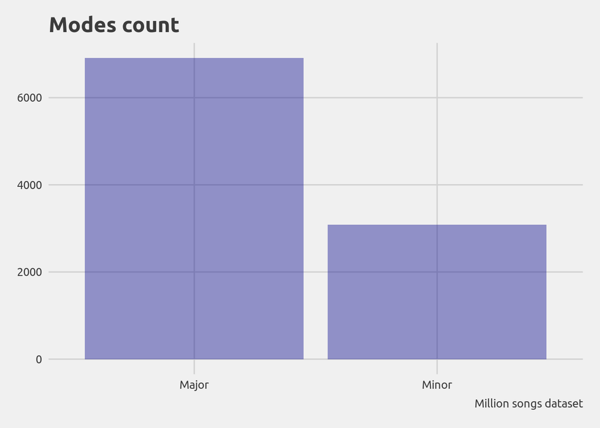

```r
df$modeString[df$mode==1] <- "Major"
df$modeString[df$mode==0] <- "Minor"

ggplot(df, aes(x=modeString)) +
  geom_histogram(stat = "count", fill = "dark blue", alpha=0.4)+
  theme_fivethirtyeight() +
  theme(text = element_text(family = 'Ubuntu', size = 12)) +
  labs(
    title = "Modes count",
    caption = "Million songs dataset"
   )
```

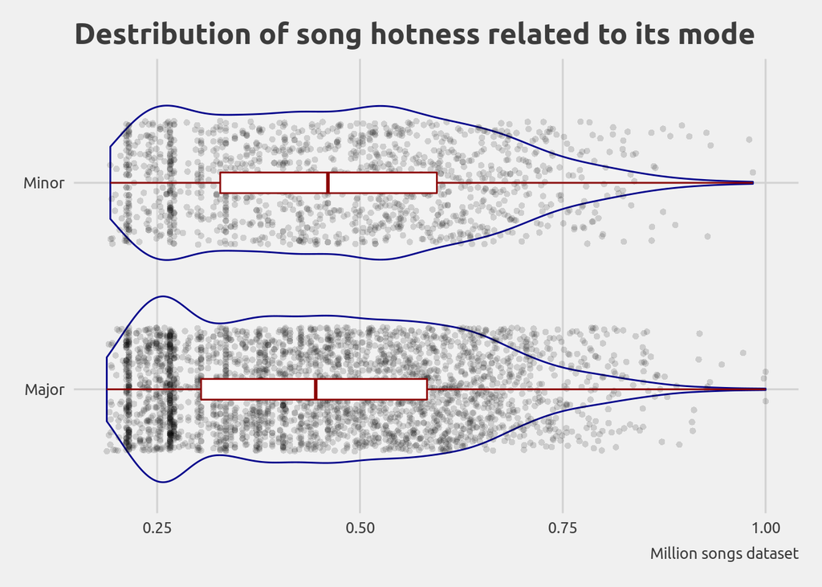

```r
df %>%
  select(modeString, song.hotttnesss) %>%
  filter_at(vars(song.hotttnesss), any_vars(. != 0)) %>%
  na.omit() %>%
  ggplot(aes(x=modeString, y=song.hotttnesss)) +
  geom_violin(alpha=.1, color='dark blue') +
  geom_jitter(shape=16, position=position_jitter(0.3), alpha = 0.15) +
  geom_boxplot(width=0.1, color='dark red') +
  coord_flip() +
  theme_fivethirtyeight() +
  theme(
    text = element_text(family = 'Ubuntu', size = 12)
  ) +
  labs(
    title = "Destribution of song hotness related to its mode",
    caption = "Million songs dataset"
  )
```

As we can conclude, we songs in **minor** is little bit **more popular**, than songs is **major**. But overall pattern is alomost identical.

### Lets see how median song duration changed over time:

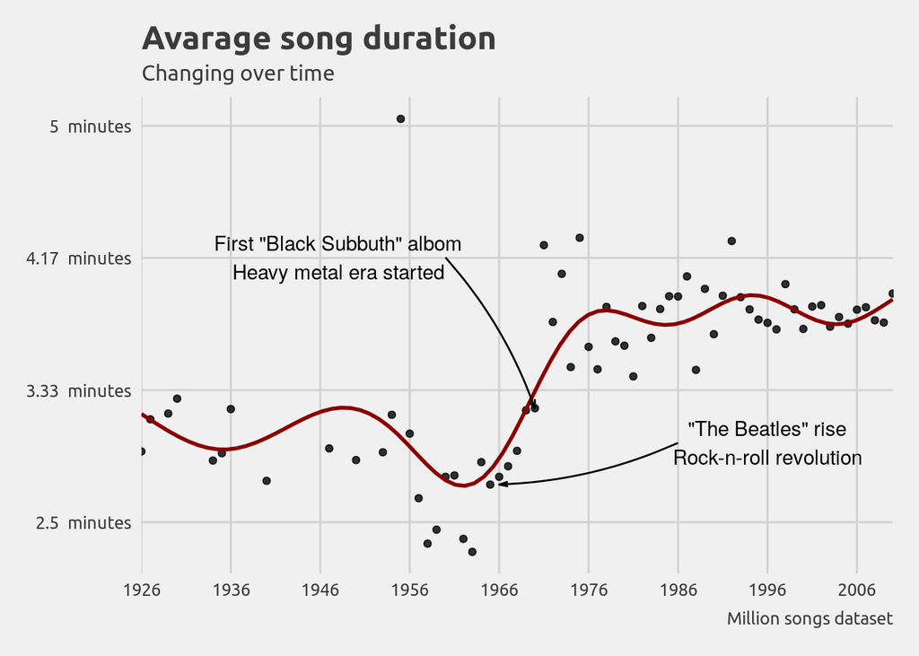

```r
dgr_fmt <- function(x) {
  parse(text = sprintf("%.2f~minutes", x/60))
}

df2 <- df[df$year != 0,] %>% select(c("duration", "year"))

aggregate(df2, by=list(df2$year), median) %>%
  ggplot(aes(x=year)) +
    geom_point(mapping = aes(y=duration), alpha = 0.8) +
    geom_smooth(method = "gam", formula = y ~ s(x), mapping = aes(y=duration), se=F, color='darkred') +
    theme_fivethirtyeight() +
    theme(text = element_text(family = 'Ubuntu', size = 12)) +
    scale_x_continuous(
      breaks = seq(min(df2$year), max(df2$year), 10),
      expand = c(0, 0, 0, 0),
      minor_breaks = F
    ) +
    scale_y_continuous(
      label = dgr_fmt
    ) +
    geom_curve(data = data.frame(x = 1986, y = 3 * 60, xend = 1965 + 1, yend = median(df2[df2$year == 1965,]$duration)),
            aes(x = x, y = y, xend = xend, yend = yend),
            curvature = -0.1,
            arrow = arrow(angle = 15, length = unit(5, 'pt')),
            inherit.aes = FALSE) +
    geom_text(
      data = data.frame(x = 1980, y = 3 * 60, label = '"The Beatles" rise\nRock-n-roll revolution'),
      aes(x = x, y = y, label = label),
      inherit.aes = FALSE, nudge_x = 16
    ) +
    geom_curve(data = data.frame(x = 1960, y = 4.17 * 60, xend = 1970, yend = median(df2[df2$year == 1970,]$duration)),
            aes(x = x, y = y, xend = xend, yend = yend),
            curvature = -0.1,
            arrow = arrow(angle = 20, length = unit(5, 'pt')),
            inherit.aes = FALSE) +
    geom_text(
      data = data.frame(x = 1960, y = 4.17 * 60, label = 'First "Black Subbuth" albom\nHeavy metal era started'),
      aes(x = x, y = y, label = label),
      inherit.aes = FALSE, nudge_x = -12
    ) +
    labs(
      title = "Avarage song duration",
      subtitle = "Changing over time",
      caption = "Million songs dataset"
    )
```

As we could see avarage duration of songs has songs tend to be **below 3 minutes** before **mid 60th**. After the rock-n-roll rise it become **approximately 4 minutes since than**.

### Lets see how median song tempo changed over time:

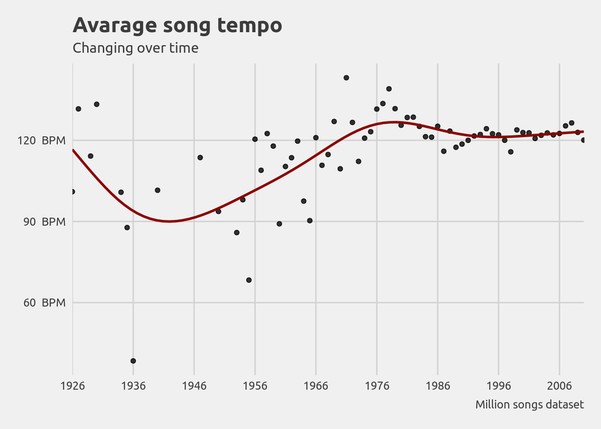

```r
dgr_fmt <- function(x) {
  parse(text = sprintf("%.2f~BPM", x))
}

df2 <- df[df$year != 0,] %>% select(c("tempo", "year"))

aggregate(df2, by=list(df2$year), median) %>%
  ggplot(aes(x=year)) +
    geom_point(mapping = aes(y=tempo), alpha = 0.8) +
    geom_smooth(method = "gam", formula = y ~ s(x), mapping = aes(y=tempo), se=F, color='darkred') +
    theme_fivethirtyeight() +
    theme(text = element_text(family = 'Ubuntu', size = 12)) +
    scale_x_continuous(
      breaks = seq(min(df2$year), max(df2$year), 10),
      expand = c(0, 0, 0, 0),
      minor_breaks = F
    ) +
    scale_y_continuous(
      label = dgr_fmt
    ) +
    labs(
      title = "Avarage song tempo",
      subtitle = "Changing over time",
      caption = "Million songs dataset"
    )
```

Avarage tempo of songs has **started raising** from **mid 40th** and reached **120 BPM** and approximately stays on this level now.

### Lets see how populer different genres of music are:

```r
genres <- as_data_frame(table(genre = df[df$terms != 'Not available',]$terms))
```

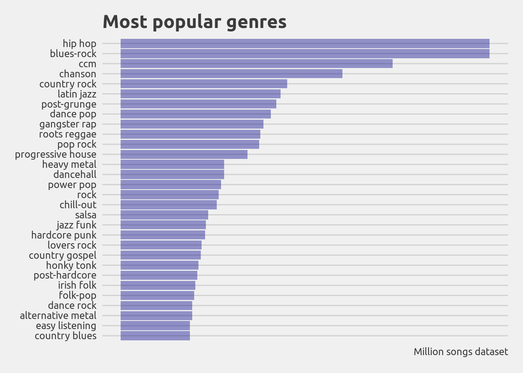

```r
genres[order(-genres$n), ] %>% slice(1:30) %>%
  ggplot(aes(x=reorder(genre, n), y=n)) +
  geom_bar(stat = "identity", fill = "dark blue", alpha=0.4)+
  coord_flip()+
  theme_fivethirtyeight() +
  theme(text = element_text(family = 'Ubuntu', size = 12)) +
  scale_y_continuous(breaks = NULL) +
  labs(
    title = "Most popular genres",
    caption = "Million songs dataset"
   )
```

### Lets where the artists are from:

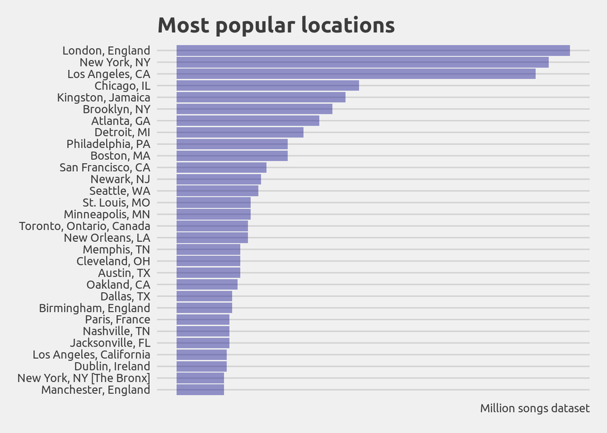

```r
geo_available <- as_data_frame(table(location = df[df$location != 'Not available',]$location))
geo_available <- geo_available[order(-geo_available$n), ]

most_popular_location <-
  geo_available[grep(",", geo_available$location),] %>%
  slice(1:30)

most_popular_location %>% ggplot(aes(x=reorder(location, n), y=n)) +
  geom_bar(stat = "identity", fill = "dark blue", alpha=0.4) +
  coord_flip()+
  theme_fivethirtyeight() +
  theme(text = element_text(family = 'Ubuntu', size = 12)) +
  scale_y_continuous(breaks = NULL) +
  labs(
    title = "Most popular locations",
    caption = "Million songs dataset"
   )
```

As we could see **UK** and **USA** creates the most popular music (according to this dataset)

### Lets draw the distribution of songs over the worlds map:

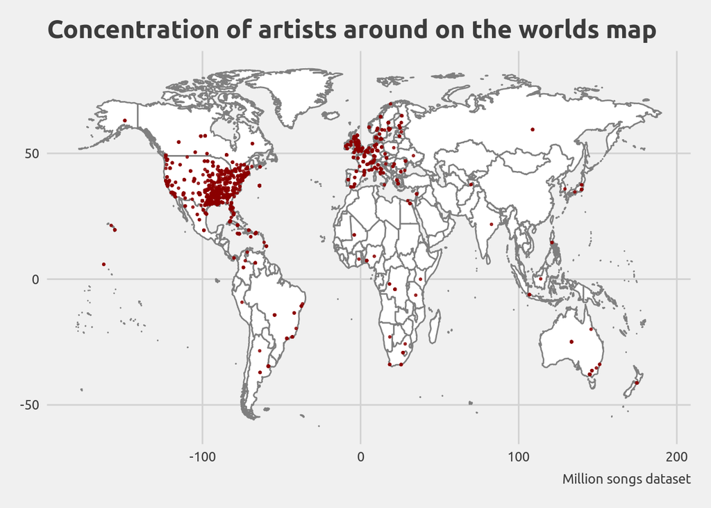

```r
df3 <- df[df$location != 'Not available',]
WorldData <- map_data('world')
WorldData %>% filter(region != "Antarctica") -> WorldData
WorldData <- fortify(WorldData)

ggplot() +
  geom_map(data=WorldData, map=WorldData,
    aes(x=long, y=lat, group=group, map_id=region),
    fill="white", colour="#7f7f7f", size=0.5
  ) +
  geom_point(data = df3, aes(x = longitude, y = latitude), col="dark red", size=.5, alpha = .8) +
  theme_fivethirtyeight() +
  theme(text = element_text(family = 'Ubuntu', size = 12)) +
  labs(
    title = "Concentration of artists around on the worlds map",
    caption = "Million songs dataset"
   )
```

Most of the music are produced in **USA east coast** and **Western Europe** (according to dataset).